# Rstudio Table Contest Submission

And impressions of the {gt} package.

EE https://www.ericekholm.com/  
10-26-2020

Anyway, below is my submission to the contest, and below that are some initial impressions of the `{gt}` package (tl;dr – it’s pretty awesome).

## Table

**Top Earning Broadway Shows**

*through 2019*

Rank

Show

Premiere Year

Total Earnings

Avg Theater  
Capacity Filled

Tickets Sold Per Year

Average

1987 - 2019

1

The Lion King

[figure not shown]

1997

$1.66B

97.7%

676,795

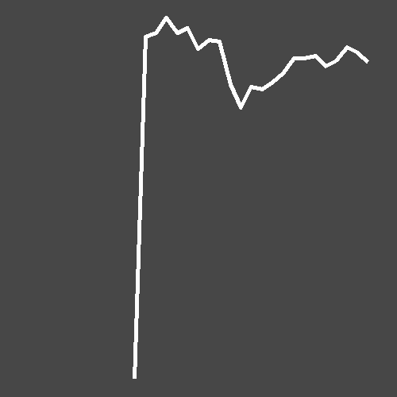

2

Wicked

[figure not shown]

2003

$1.35B

97.2%

708,412

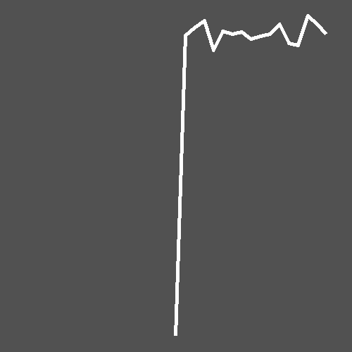

3

The Phantom of the Opera

[figure not shown]

1988

$1.24B

89.8%

600,508

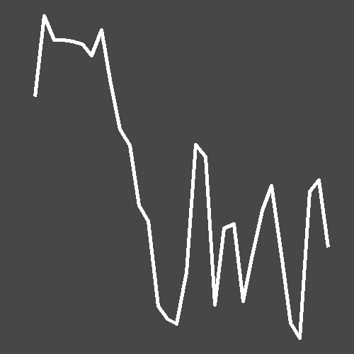

4

Chicago

[figure not shown]

1996

$673.91M

82.7%

392,534

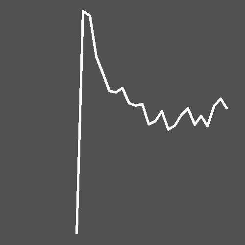

5

The Book of Mormon

[figure not shown]

2011

$647.07M

102.4%

445,435

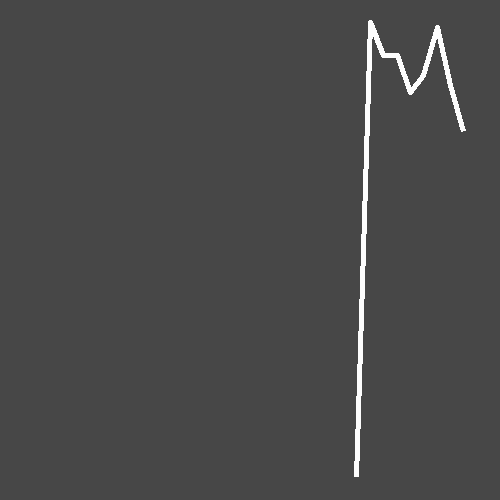

6

Mamma Mia!

[figure not shown]

2001

$624.39M

89.7%

504,408

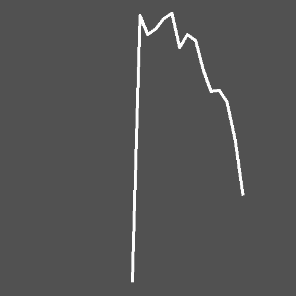

7

Hamilton

[figure not shown]

2015

$620.60M

101.7%

498,052

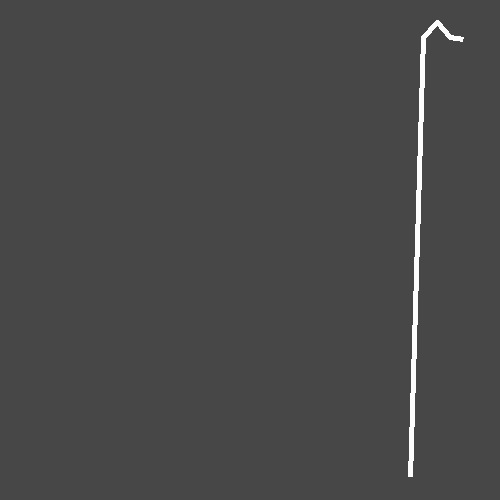

8

Jersey Boys

[figure not shown]

2005

$557.51M

89.5%

395,571

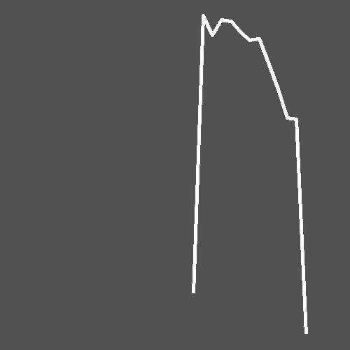

9

Les Miserables

[figure not shown]

1987

$548.80M

88.5%

353,014

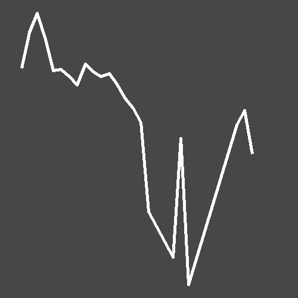

10

Aladdin

[figure not shown]

2014

$447.72M

98.0%

686,539

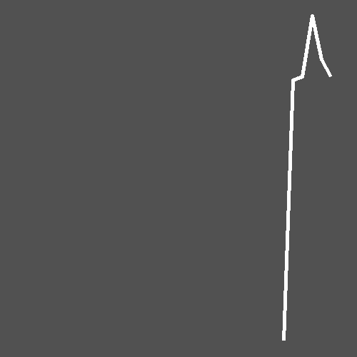

**Data:** Playbill | **Table:** Eric Ekholm (@ekholm_e)

## Impressions

Right, so, my overall impression of `{gt}` is that it’s an amazing package for building stylized static tables that fills a gap in R’s table ecosystem (to the extent that’s a thing). In my day job, I often find myself having to build tables either 1) as part of documents I’m creating on my own or 2) as stand-alone pieces that end up getting dropped into Powerpoints other people are putting together, and I’m excited about incorporating `{gt}` into my workflow for both of those types of tasks. Some more specific impressions of `{gt}`:

- It feels a lot like `{ggtplot2}`. This isn’t surprising, given that the intent of the package is to provide a “grammar of tables.” But the flow & general process felt very familiar to me even though I haven’t used it extensively before, and I imagine anyone else who’s reasonably proficient using ggplot will feel the same when picking up gt. Which is a big plus, because it mitigates a lot of that difficulty of learning a new package.
- It’s refreshingly easy to work with fonts. My biggest sore spot with ggplot is incorporating different fonts, which I always seem to struggle with (and my understanding is that this is a common struggle for Windows users). The `{ragg}` package seems to have made using fonts in ggplot easier, though. That said, using any Google font in gt is as easy as dropping in the `google_font()` function and voila, it works! Such a nice change of pace after my typical long troubleshooting sessions with fonts in ggplot.
- The ability to include ggplot images and web images in a table is pretty cool. You’ll see that I added both to my table above, and each felt very easy to include. Honestly, the most time-consuming part was finding the urls for the playbill images.
- The helper functions to format numbers, percents, and currency are great. I work with a lot of large $ amounts – as well as percents – in my job, and I’m super stoked about not having to manually format these anymore.
- I may have run into a small bug passing where font types (e.g. Lobster, Rubik) weren’t being recognized when called from within a list in the `tab_style()` function, which I’ll open an issue for. I found a workaround, but it involved essentially stylizing the same element multiple times, which doesn’t feel ideal.

Overall, `{gt}` is a really awesome package – huge thanks to the team at Rstudio for putting it together and maintaining it!

Enjoying this blog? Get notified of new posts via email: